# R Assignment 4: Conceptual Replication

## Part 5 (Assignment 4.5)

### Goal: Replicate Descriptive Statistics (Table 1) from Orcutt (1987) for Earlier Waves of NYS

We have just walked you through a conceptual replication of Orcutt’s (1987) descriptive statistics using wave 6 of the NYS—the wave where NYS respondents were presumably most similar in age to Orcutt’s sample. Substantively, this was an attempt to see if Orcutt’s findings generalized to a nationally representative sample. But another substantive question to address related to Orcutt’s findings is how the results would generalize to different age-groups.

##### 1. Use earlier wave of NYS to perform your own conceptual replication of Orcutt (1987)

To examine the question of whether Orcutt’s findings generalize to different age groups, one basic thing we can do is perform a similar conceptual replication using earlier waves of the NYS (waves 1 - 5). This is now your task.

- Using Jake’s cool code, I (Jon) have randomly assigned each of you to one of the first five waves of the NYS and provided you with a pooled data set called “nys_fwtrim_orc1987” (see assignment on Canvas to download directly and/or for the script used to create the data set). The data set includes the following variables:

| variable | question | answers |
| --- | --- | --- |
| CASEID | Unique Identifier | NA |
| wave | Wave of NYS data collection | NA |
| age | How old are you? | specific age |
| marpeer | Think of your friends. During the last year how many of them have used marijuana or hashish? | 1 = None of them - 5 = All of them |
| mardef | How wrong is it for someone your age to use marijuana or hashish? | 1 = Not wrong - 4 = Very wrong |
| maruse | In the last year, how often have you used marijuana - hashish ('grass', 'pot', 'hash')? | 1 = Never - 9 = 2 to 3 times/day |

- *Note:* In the first five waves, the NYS only asked about marijuana use in the last year and not about whether the respondents’ got high from marijuana in the past year.
- *Note:* Also note that they did not ask for a raw count in Waves 1 and 2 and instead asked for them to answer on a 9-point scale that ranged from 1 = “Never” to 9 = “2 to 3 times per day”. Here is the full range of answers from the Wave 1 codebook:

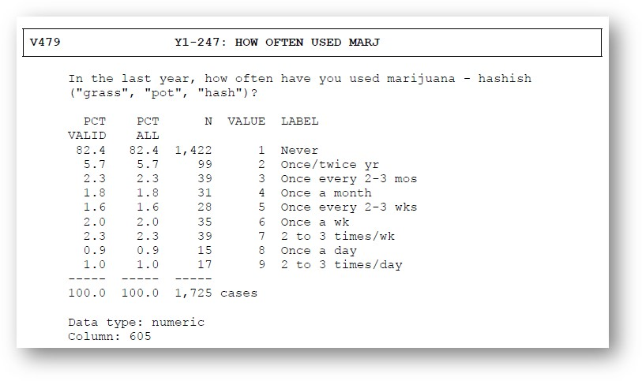

- *Note:* This question was also included in wave 6 (V891), but it was only asked of those who reported using marijuana 10 or more times in the last year.
- *Note:* Given the first five waves of the NYS did not ask about getting high from marijuana this is another instance where the conceptualization of “marijuana use” in your replication with one of the first five waves of data will be different from Orcutt’s conceptualization. But note that with this measure you are still able to distinguish between those who have used marijuana at all in the past year and those who have not.

##### 2. NYS Wave Assignments

Here are your wave assignments:

| NYS Wave | Students | Students | Students |
| --- | --- | --- | --- |
| Wave 1 | Student 4 | Student 10 | Student 3 |
| Wave 2 | Student 1 | Student 8 | NA |
| Wave 3 | Student 9 | Student 6 | NA |
| Wave 4 | Student 7 | Student 2 | NA |
| Wave 5 | Student 11 | Student 5 | NA |

- *Note:* Remember, you are only responsible for performing a conceptual replication of Orcutt (1987) using the specific wave to which you are assigned.

##### 3. “Draw the Owl”

You should now have everything that you need to replicate Orcutt’s (1987) Table 1 with the NYS data to which you were assigned. The pooled data set is provided with the assignment on canvas (along with the R Script used to create it). If you have followed along up to this point, you should have all the requisite skills to recreate Table 1 above using the NYS wave to which you were assigned.

All that is left to do is:

1. Download the pooled datafile from canvas then load the pooled data into R.
- *Note:* The pooled datafile on Canvas is already saved as an R data object (`.rds` format). I recommend saving the pooled file in your “NYS” subfolder and then using the `load()` function as follows:
- `load(here('Datasets/NYS', 'nys_fwtrim_orc1987.rds'))`
2. Filter the pooled data to only include the wave you were assigned (see “R Assignment 3” if you forgot how to do this).
3. Recode the data in your wave to match the logic of Orcutt and what we did with wave 6 above.
4. Create a table using the “gt” package that summarizes the data similar to Orcutt and what we did above with wave 6.
5. Explain how the results of your conceptual replication are similar to or different from Orcutt’s analysis and how they are similar or different to the conceptual replication presented above for wave 6 of the NYS.

Remember:

1. Keep the file clean and easy to follow by using RMD level headings (e.g., denoted with ## or ###) separating R code chunks, organized by assignment parts or questions.
2. Write plain text after headings and before or after code chunks to explain what you are doing. This is not just for my sake - such text will serve as useful reminders to *you* when working on later assignments!
3. Upon completing the assignment, “knit” your final RMD file again and save the final knitted **html** document to your “Assignments” folder in your LastName_P680_work folder as: **LastName_P680_Assign4_YEAR_MO_DY**.
4. Inside the “LastName_P680_commit” folder in our shared folder, create another folder named: **Assignment 4**.
5. To submit your assignment for grading, save copies of both your (1) final knitted “Assign4” html file and (2) your “Assign4_RMD” file into the “LastName_P680_commit / Assignment 4” folder.
   - Remember, be sure to save *copies* of both files - do not just drag the files over from your “work” folder, or you may lose those original copies from your “work” folder.